# BIRAX study - TASMC descriptive statistics

David M Wright - d.wright@qub.ac.uk

Document compiled: 2023-07-20

R version 4.3.0 (2023-04-21 ucrt)

# 1 Introduction

This analysis is of Electronic Medical Records (EMR) from the Tel Aviv Sourasky Medical Centre extracted over the period 2014-04-27 to 2022-07-31. The aim of the study is to investigate the potential for machine learning to identify factors and biomarkers associated with long-term AMD treatment response.

This document gives descriptive statistics for various sub-groups in the dataset.

# 2 VA change by baseline visual acuity

Table 2.1: Distribution of VA changes (logMAR from baseline) at end of each year of anti-VEGF treatment.

| Category | Level | 1 | 2 | 3 | 4 | 5 |
| --- | --- | --- | --- | --- | --- | --- |
| Good (VA>6/12) | Mean (SD) | -0.13 (0.3) | -0.14 (0.34) | -0.15 (0.32) | -0.15 (0.34) | -0.2 (0.32) |
| Moderate (6/24 < VA <= 6/12) | Mean (SD) | -0.09 (0.33) | -0.057 (0.31) | -0.098 (0.33) | -0.19 (0.42) | 0.032 (0.34) |
| Partially sighted (6/60 < VA <= 6/24) | Mean (SD) | 0.015 (0.46) | 0.089 (0.43) | 0.038 (0.45) | 0.18 (0.51) | 0.28 (0.52) |
| Blind (VA <= 6/60) | Mean (SD) | 0.33 (0.57) | 0.44 (0.58) | 0.49 (0.7) | 0.65 (0.59) | 0.54 (0.69) |
| Good (VA>6/12) | n | 230 | 185 | 129 | 84 | 33 |
| Moderate (6/24 < VA <= 6/12) | n | 108 | 77 | 45 | 23 | 4 |
| Partially sighted (6/60 < VA <= 6/24) | n | 95 | 77 | 54 | 30 | 8 |
| Blind (VA <= 6/60) | n | 151 | 114 | 74 | 40 | 9 |

Table 2.2: Distribution of VA change categories (from baseline) at the end of each year of anti-VEGF treatment. Ceiling effects not adjusted for.

| va_category_snellen | Level | 1 | 2 | 3 | 4 | 5 |
| --- | --- | --- | --- | --- | --- | --- |
| Good (VA>6/12) | Good (gained >5 letters) | 78 (33.9%) | 62 (33.5%) | 46 (35.7%) | 29 (34.5%) | 17 (51.5%) |
| Good (VA>6/12) | Partial (-5<=change<=5 letters) | 138 (60%) | 107 (57.8%) | 74 (57.4%) | 47 (56%) | 14 (42.4%) |
| Good (VA>6/12) | Non-response (lost > 5 letters) | 14 (6.09%) | 16 (8.65%) | 9 (6.98%) | 8 (9.52%) | 2 (6.06%) |
| Good (VA>6/12) | n | 230 (100%) | 185 (100%) | 129 (100%) | 84 (100%) | 33 (100%) |
| Moderate (6/24 < VA <= 6/12) | Good (gained >5 letters) | 44 (40.7%) | 28 (36.4%) | 19 (42.2%) | 9 (39.1%) | 1 (25%) |
| Moderate (6/24 < VA <= 6/12) | Partial (-5<=change<=5 letters) | 31 (28.7%) | 24 (31.2%) | 10 (22.2%) | 8 (34.8%) | 0 (0%) |
| Moderate (6/24 < VA <= 6/12) | Non-response (lost > 5 letters) | 33 (30.6%) | 25 (32.5%) | 16 (35.6%) | 6 (26.1%) | 3 (75%) |
| Moderate (6/24 < VA <= 6/12) | n | 108 (100%) | 77 (100%) | 45 (100%) | 23 (100%) | 4 (100%) |
| Partially sighted (6/60 < VA <= 6/24) | Good (gained >5 letters) | 30 (31.6%) | 25 (32.5%) | 16 (29.6%) | 7 (23.3%) | 1 (12.5%) |
| Partially sighted (6/60 < VA <= 6/24) | Partial (-5<=change<=5 letters) | 24 (25.3%) | 11 (14.3%) | 8 (14.8%) | 5 (16.7%) | 0 (0%) |
| Partially sighted (6/60 < VA <= 6/24) | Non-response (lost > 5 letters) | 41 (43.2%) | 41 (53.2%) | 30 (55.6%) | 18 (60%) | 7 (87.5%) |
| Partially sighted (6/60 < VA <= 6/24) | n | 95 (100%) | 77 (100%) | 54 (100%) | 30 (100%) | 8 (100%) |
| Blind (VA <= 6/60) | Good (gained >5 letters) | 35 (23.2%) | 20 (17.5%) | 16 (21.6%) | 3 (7.5%) | 0 (0%) |
| Blind (VA <= 6/60) | Partial (-5<=change<=5 letters) | 27 (17.9%) | 20 (17.5%) | 10 (13.5%) | 6 (15%) | 4 (44.4%) |
| Blind (VA <= 6/60) | Non-response (lost > 5 letters) | 89 (58.9%) | 74 (64.9%) | 48 (64.9%) | 31 (77.5%) | 5 (55.6%) |
| Blind (VA <= 6/60) | n | 151 (100%) | 114 (100%) | 74 (100%) | 40 (100%) | 9 (100%) |

# 3 Phases of functional response

The response to treatment in terms of visual acuity change can be divided into three phases:

- Primary response - measured at the first visit after the third anti-VEGF injection.
- Secondary response - measured at the second visit after the third anti-VEGF injection, provided this visit was <12 months since the first injection.
- Late response - measured at the first visit in the second year since the first injection.

The distribution of VA measurements across the phases is given in Figure 3.1. Changes in treatment response between phases are described in Tables 3.1 and 3.2.

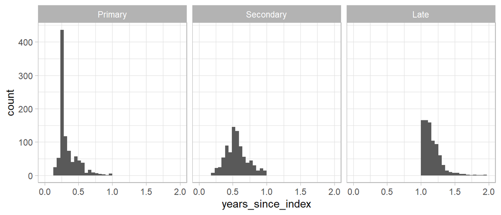

Figure 3.1: Timing of VA measurements used to represent phases of treatment response.

Table 3.1: Visual acuity changes relative to baseline in the primary and secondary phases of treatment response. Columns indicate response in the secondary phase.

| Variable | Level | Good (gained >5 letters) | Partial (-5<=change<=5 letters) | Non-response (lost > 5 letters) | NA |
| --- | --- | --- | --- | --- | --- |
| Primary | Good (gained >5 letters) | 139 (65%) | 46 (19.7%) | 20 (11.1%) | 16 (18.6%) |
| Primary | Partial (-5<=change<=5 letters) | 56 (26.2%) | 154 (65.8%) | 52 (28.9%) | 27 (31.4%) |
| Primary | Non-response (lost > 5 letters) | 19 (8.88%) | 34 (14.5%) | 108 (60%) | 17 (19.8%) |

Table 3.2: Visual acuity changes relative to baseline in the secondary and late phases of treatment response. Columns indicate response in the late phase.

| Variable | Level | Good (gained >5 letters) | Partial (-5<=change<=5 letters) | Non-response (lost > 5 letters) | NA |
| --- | --- | --- | --- | --- | --- |
| Secondary | Good (gained >5 letters) | 120 (62.2%) | 41 (17.7%) | 27 (13.9%) | 26 (27.1%) |
| Secondary | Partial (-5<=change<=5 letters) | 34 (17.6%) | 129 (55.8%) | 45 (23.2%) | 26 (27.1%) |
| Secondary | Non-response (lost > 5 letters) | 30 (15.5%) | 38 (16.5%) | 98 (50.5%) | 14 (14.6%) |